# Tutorial on Meta-analysis in R

Brian

5/21/2021

#### Purpose

Analyze results from multiple studies for generating results with larger samples.

#### Required Packages

For conducting the Meta-analysis in R, we need to use a package such as **meta**, **metafor**, and **rmeta**, etc.

We use **meta** package for this tutorial.

#### Step 1. Load package

```r
library(meta)
```

#### Step 2. Load data

Download sample_data.csv from repository into project folder.

```r
data_con <- read.csv("sample_data.csv", header=TRUE)
```

Data

For meta-analysis, data for experiment group and control group are required. Specifically, number of samples, mean, and standard deviation for each group are necessary.

n1,m1,s1 are data for experimental group and n2,m2,s2 for control group. g is for subgroup testing.

- n: number of samples
- m: mean
- s: standard deviation

| study | n1 | m1 | s1 | n2 | m2 | s2 | md | sd | g |
| --- | --- | --- | --- | --- | --- | --- | --- | --- | --- |
| S1 | 7 | 23.20 | 4.20 | 5 | 39.00 | 7.40 | -15.80 | 5.699825 | 1 |
| S2 | 12 | 28.20 | 0.90 | 11 | 35.90 | 1.40 | -7.70 | 1.165169 | 1 |
| S3 | 8 | 27.90 | 2.00 | 10 | 33.40 | 1.20 | -5.50 | 1.600000 | 1 |
| S4 | 10 | 27.90 | 2.00 | 9 | 36.10 | 2.70 | -8.20 | 2.355469 | 1 |
| S5 | 10 | 43.40 | 5.71 | 5 | 61.80 | 9.41 | -18.40 | 7.058161 | 0 |
| S6 | 9 | 53.10 | 7.88 | 5 | 61.80 | 9.41 | -8.70 | 8.420944 | 0 |
| S7 | 9 | 9.70 | 4.11 | 11 | 9.60 | 4.20 | 0.10 | 4.160240 | 1 |
| S8 | 6 | 10.33 | 4.50 | 9 | 8.11 | 7.39 | 2.22 | 6.433965 | 1 |
| S9 | 8 | 33.82 | 3.79 | 8 | 40.74 | 3.97 | -6.92 | 3.881044 | 0 |
| S10 | 9 | 36.21 | 1.72 | 10 | 42.32 | 4.07 | -6.11 | 3.187764 | 1 |
| S11 | 6 | 37.21 | 2.04 | 10 | 42.32 | 4.07 | -5.11 | 3.483554 | 1 |

#### Step 3. Run Meta-analysis

We used SMD and Hedges method.

- sm:
  - MD (mean difference)
  - **SMD (standardized mean difference)**
  - ROM (ratio of means)
- method.smd:
  - **Hedges**
  - Cohen
  - Glass

Additionally, g is used for subgroup analysis.

```r
ma_con <- metacont(n.e=n1, mean.e=m1, sd.e=s1, n.c=n2, mean.c=m2, sd.c=s2, sm="SMD", method.smd="Hedges", study,
                    byvar=g ,data=data_con)
print(ma_con , digits=3)
```

```
##        SMD           95%-CI %W(fixed) %W(random) g
## S1  -2.559 [-4.255; -0.863]       4.9        8.2 1
## S2  -6.370 [-8.551; -4.188]       3.0        6.9 1
## S3  -3.274 [-4.800; -1.748]       6.1        8.7 1
## S4  -3.325 [-4.816; -1.835]       6.3        8.8 1
## S5  -2.454 [-3.936; -0.971]       6.4        8.8 0
## S6  -0.967 [-2.139;  0.205]      10.3        9.6 0
## S7   0.023 [-0.858;  0.904]      18.2       10.3 1
## S8   0.325 [-0.717;  1.367]      13.0        9.9 1
## S9  -1.686 [-2.874; -0.497]      10.0        9.5 0
## S10 -1.831 [-2.944; -0.718]      11.4        9.7 1
## S11 -1.387 [-2.540; -0.233]      10.6        9.6 1
##
## Number of studies combined: k = 11
##
##                         SMD           95%-CI     z  p-value
## Fixed effect model   -1.456 [-1.832; -1.081] -7.60 < 0.0001
## Random effects model -1.973 [-2.897; -1.048] -4.18 < 0.0001
##
## Quantifying heterogeneity:
##  tau^2 = 1.9634 [0.9234; 8.3965]; tau = 1.4012 [0.9610; 2.8977]
##  I^2 = 82.7% [70.3%; 89.9%]; H = 2.40 [1.83; 3.14]
##
## Test of heterogeneity:
##      Q d.f.  p-value
##  57.66   10 < 0.0001
##
## Results for subgroups (fixed effect model):
##         k    SMD           95%-CI     Q   I^2
## g = 1   8 -1.407 [-1.845; -0.968] 55.06 87.3%
## g = 0   3 -1.594 [-2.321; -0.867]  2.41 17.1%
##
## Test for subgroup differences (fixed effect model):
##                    Q d.f.  p-value
## Between groups  0.19    1   0.6655
## Within groups  57.48    9 < 0.0001
##
## Results for subgroups (random effects model):
##         k    SMD           95%-CI  tau^2    tau
## g = 1   8 -2.139 [-3.410; -0.867] 2.8537 1.6893
## g = 0   3 -1.610 [-2.413; -0.808] 0.0870 0.2949
##
## Test for subgroup differences (random effects model):
##                     Q d.f. p-value
## Between groups   0.47    1  0.4909
##
## Details on meta-analytical method:
## - Inverse variance method
## - DerSimonian-Laird estimator for tau^2
## - Jackson method for confidence interval of tau^2 and tau
## - Hedges' g (bias corrected standardised mean difference)
```

The results consist of three parts: SMD, heterogeneity, subgroup.

#### SMD

- H0: Intervention is not effective(No difference)
- H1: Intervention is effective

For both fixed effect model and random effects model, the p-value is less than 0.001.

#### Heterogeneity

Regarding test of heterogeneity,

- H0: Heterogeneity does not exist
- H1: Heterogeneity exist

I^2 is 82.7%, p-value of Q is less than 0.001. It indicates that heterogeneity exist. In general, random effects model is preferred when heterogeneity exist.

#### Forest plot.

Forest plot is a visual tool to check heterogeneity among studies. Additionally, it shows the overall effect size using diamond symbol in the plot.

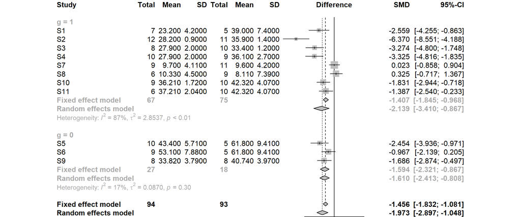

```r
forest(ma_con, comb.fixed=TRUE, comb.random=TRUE,digits=3,
      rightcols=c("effect", "ci"))
```

Meta-regression is a statistical tool to check what causes heterogeneity.

- H0: Heterogeneity does not exist
- H1: Heterogeneity exist
- method.tau (method to estimate the between-study variance tau-squared)
  - REML (restricted maximum likelihood)
  - ML (maximum likelihood)

```r
metareg(ma_con, g, method.tau="REML", digits=3)
```

```
##
## Mixed-Effects Model (k = 11; tau^2 estimator: REML)
##
## tau^2 (estimated amount of residual heterogeneity):     2.724 (SE = 1.514)
## tau (square root of estimated tau^2 value):             1.651
## I^2 (residual heterogeneity / unaccounted variability): 86.73%
## H^2 (unaccounted variability / sampling variability):   7.54
## R^2 (amount of heterogeneity accounted for):            0.00%
##
## Test for Residual Heterogeneity:
## QE(df = 9) = 57.476, p-val < .001
##
## Test of Moderators (coefficient 2):
## QM(df = 1) = 0.137, p-val = 0.711
##
## Model Results:
##
##          estimate     se    zval   pval   ci.lb  ci.ub
## intrcpt    -1.686  1.025  -1.644  0.100  -3.695  0.324
## g          -0.447  1.207  -0.371  0.711  -2.812  1.918
##
## ---
## Signif. codes:  0 '***' 0.001 '**' 0.01 '*' 0.05 '.' 0.1 ' ' 1
```

#### Test of Moderators (coefficient 2)

- H0: No difference(NO moderation effect)
- H1: Different(Moderation effect)

The p-value of ‘Test of Moderators’ is 0.711(>0.05), which indicates g does not moderate.

Bubble plot

The results of meta-regression analysis is presented in bubble plot. The line in the plot represent regression result.

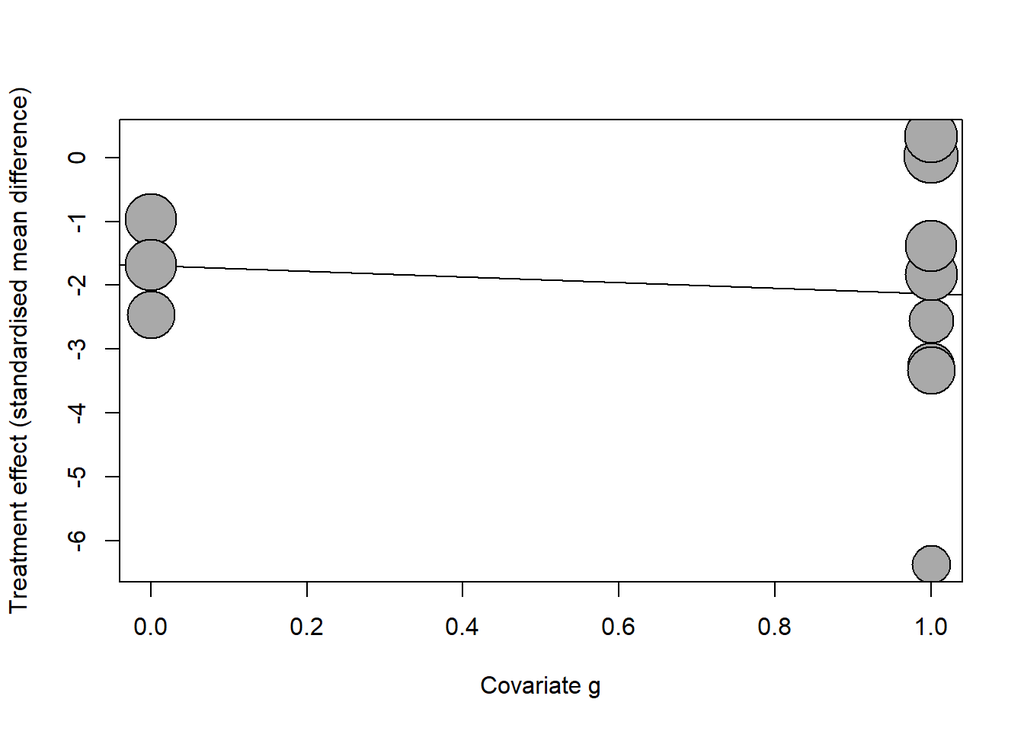

```r
bubble(metareg(ma_con, g, method.tau="REML"))
```

#### Statistical method: Funnel plot

Funnel plot is a visual tool to determine whethere there is a publication bias or not. If the data in the funnel is not symmetric, it indicates that publication bias may exist.

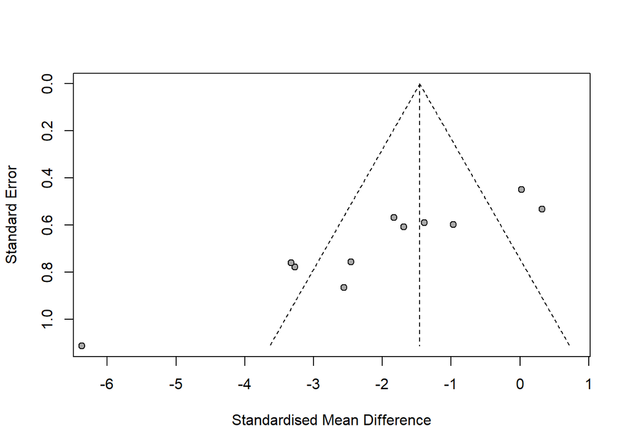

```r
funnel(ma_con, comb.fixed=TRUE, comb.random=FALSE)
```

#### Statistical methods: Egger’s test, Begg’s test

Run Meta-analysis again without subgroup. The results is used for testing publication bias.

```r
ma_con <- metacont(n1, m1, s1, n2, m2, s2, sm="SMD", method.smd="Hedges",
                   study,data=data_con)
```

#### Egger’s test

- H0: Publication bias does not exist
- H1: Publication bias exist

```r
metabias(ma_con, method.bias="linreg")
```

```
## Linear regression test of funnel plot asymmetry
##
## Test result: t = -6.92, df = 9, p-value < 0.0001
##
## Sample estimates:
##     bias se.bias intercept se.intercept
##  -9.2328  1.3344    4.2545       0.8476
##
## Details:
## - multiplicative residual heterogeneity variance (tau^2 = 1.0139)
## - predictor: standard error
## - weight:    inverse variance
## - reference: Egger et al. (1997), BMJ
```

The p-value is less than 0.001, which indicates H0 is rejected.

#### Begg’s test

- H0: Publication bias does not exist
- H1: Publication bias exist

```r
metabias(ma_con, method.bias="rank")
```

```
## Rank correlation test of funnel plot asymmetry
##
## Test result: z = -3.04, p-value = 0.0024
##
## Sample estimates:
##        ks   se.ks
##  -39.0000 12.8452
##
## - reference: Begg & Mazumdar (1993), Biometrics
```

The p-value(0.0024) is less than 0.05, which indicates H0 is rejected.

#### What if publication bias exist?

- Add more data, then analyze again.
- Run sensitivity analysis

#### Summary

- Effect size.
- SMD
  - Cohen’s d
  - Hedges’ g
  - **metacont()**
- Oeverall
  - Fixed effect model
  - Random effect model (Generally, CI is wider than Fixed effect model)
  - Forest plot
    - **forest()**
- Heterogeneity.
  - Cochrane Q(p<0.1)
    - H0 : Same
    - H1 : Different
  - Higgins I2
  - **metareg()**, **bubble()**
- Publication bias.
  - Funnel plot
    - **funnel()**
  - Egger’s test
    - **metabias()**
  - Begg’s test
    - **metabias()**

#### References

- Intervention Meta-analysis: Application and Practice using R software